# Qualifier les signalements de piqûres de tiques par analyses multivariées des données paysagères

Analyse multivariée des paysages de piqûres de tiques avec CLC 2018

Author

Djibril, Lucas, Samuel

**Introduction**

**ImportantContexe de l’étude**

En France métropolitaine, les maladies vectorielles transmises par les tiques, et en particulier la borréliose de Lyme, constituent un enjeu croissant de santé publique. Entre 2019 et 2020, l’incidence de cette pathologie a augmenté de 20 %, atteignant plus de 60 000 cas annuels diagnostiqués **(CRMVT Paris-Région Nord)**.

Cette évolution est étroitement liée aux effets du changement climatique, qui modifient les conditions bioclimatiques favorables au développement de la tique Ixodes ricinus, entraînant une extension spatiale de son aire de distribution et une prolongation de sa période d’activité sur le territoire métropolitain **(INRAE - Projet Climatick, 2024).**

Dans ce contexte, ce travail vise à caractériser spatialement les « paysages de piqûre » afin d’approfondir la compréhension de l’écologie spatiale des tiques. L’objectif est d’identifier et de cartographier des profils paysagers associés aux zones de forte exposition.

L’étude repose sur l’exploitation de la base de données Corine Land Cover (CLC) au sein d’un système d’information géographique (SIG), permettant l’extraction de métriques d’occupation du sol dans des buffers optimisés autour des points de signalement de piqûres.

L’application de méthodes d’analyse multivariée conduit à la définition de typologies paysagères, offrant une confrontation objective entre les paysages analysés et les milieux déclarés, et contribuant ainsi à une meilleure compréhension spatiale de l’écologie des tiques.

# 1 Détermination de l’emprise optimale autour de point de piqûre

##configuration de workspace

## 1.1 Nettoyage de données

**Chargement de données CSV**

**Conversion des types de variables “object” avec #N/D en float64**

**Vérifier les types de variables**

```
id                      int64
lat_piq               float64
lon_piq               float64
lat_dom               float64
lon_dom               float64
distance(km)          float64
date_piqure_saisie      int64
qui_pique              object
sex_animal             object
nbr_tique               int64
precision_geo          object
environnement          object
region                 object
code_postal             Int64
summary                object
temperaturemin        float64
temperaturemax        float64
dtype: object
```

**Correction de la variable ‘environnement’**

```
environnement
Jardin privé ou parc municipal    1721
Forêt                             1250
Prairie                            682
Autre                              589
Zone agricole cultivée             255
Name: count, dtype: int64
```

**Sélection des enregistrements pour les chiens**

```
(2289, 17)
```

**Compte des valeurs non manquantes par colonne**

```
id                    2289
lat_piq               2289
lon_piq               2289
lat_dom               2090
lon_dom               2090
distance(km)          2090
date_piqure_saisie    2289
qui_pique             2289
sex_animal            2289
nbr_tique             2289
precision_geo         2289
environnement         2289
region                2289
code_postal           2289
summary               2289
temperaturemin        2289
temperaturemax        2289
dtype: int64
```

## 1.2 Distance moyenne entre domicile et lieu des piqûres pour les chiens

**Extraction des distances pour les chiens**

```
    Percentile (%)  Distance (km)
0                0           0.00
1               10           0.02
2               20           0.06
3               30           0.15
4               40           0.36
5               50           0.83
6               60           1.48
7               70           2.36
8               80           4.05
9               90           7.72
10             100         834.19
```

**TipAnalyse de la distribution des distances moyennes**

L’analyse des percentiles de la distance moyenne met en évidence une distribution fortement asymétrique à droite. La majorité des observations correspond à des distances très courtes : la médiane est de 0,83 km et 70 % des distances sont inférieures à 2,36 km. Cette concentration près de zéro indique que le comportement dominant est celui de déplacements de courte portée.

En revanche, la présence de valeurs très élevées dans la partie supérieure de la distribution entraîne un étalement important. Alors que le 90ᵉ percentile atteint seulement 7,72 km, la valeur maximale observée s’élève à 834,19 km, révélant l’existence de cas rares et extrêmes.

Ces valeurs extrêmes influencent fortement la moyenne, qui devient peu représentative de la distance typique parcourue. Dans ce contexte, l’utilisation de la médiane et des percentiles apparaît plus pertinente pour décrire le comportement central de la population étudiée.

**Comparaison de la distance moyenne sur 10 déciles et les 9 premiers déciles**

```
Moyenne distance pour chiens (10 déciles) : 8.419 km
```

```
Moyenne distance pour chiens (9 déciles) : 1.383 km
```

**TipSynthèse de distances moyennes**

La comparaison des distances moyennes calculées sur l’ensemble des déciles et sur les neuf premiers déciles met en évidence une différence substantielle. La distance moyenne incluant l’ensemble des observations s’élève à 8,419 km, tandis que celle calculée après exclusion du dixième décile est limitée à 1,383 km.

Cet écart marqué révèle une forte sensibilité de la moyenne aux valeurs extrêmes. En effet, les observations appartenant au dixième décile, correspondant aux 10 % de distances les plus élevées, exercent une influence disproportionnée sur la valeur moyenne globale.

Ces résultats confirment l’existence d’une distribution fortement asymétrique, dominée par une majorité d’observations de faible amplitude et une minorité de valeurs exceptionnellement élevées.

Ainsi, les distances associées aux neuf premiers déciles apparaissent relativement homogènes et reflètent plus fidèlement le comportement typique de la population étudiée.

Compte tenu de l’influence disproportionnée du dernier décile sur la moyenne, nous privilégions la moyenne tronquée aux 90% pour calculer rayon de 1.383 km autour de signalements des piqures de tique sur les chiens en France métropolitaine.

## 1.3 Geotraitement de données de signalements

**Création du GeoDataFrame avec géométrie**

**Reprojection du GeoDataFrame en Lambert-93**

**Création de zone tampon de 1.300 km**

## 1.4 Conversion de points en polygons

**Définir rayon_m comme géométrie principale**

**Vérification**

```
1    POLYGON ((812565.256 6533220.08, 812558.996 65...
2    POLYGON ((768674.601 6275949.058, 768668.342 6...
3    POLYGON ((636978.18 6847557.032, 636971.92 684...
4    POLYGON ((618311.511 6886258.788, 618305.252 6...
6    POLYGON ((641745.747 6741406.665, 641739.488 6...
Name: geometry, dtype: geometry
```

```
['Polygon']
```

**Suppression de la colonne rayon_m**

**Verifier les valeurs non maquantes**

```
id                    2289
lat_piq               2289
lon_piq               2289
lat_dom               2090
lon_dom               2090
distance(km)          2090
date_piqure_saisie    2289
qui_pique             2289
sex_animal            2289
nbr_tique             2289
precision_geo         2289
environnement         2289
region                2289
code_postal           2289
summary               2289
temperaturemin        2289
temperaturemax        2289
geometry              2289
dtype: int64
```

## 1.5 Export en format shapefile

**Renommer les colonnes avant export (pour rester lisible)**

**Definition de dossier de sauvegarde**

**Sauvergarde en format SHP**

# 2 Analyse multivariée de l’occupation du sol

## 2.1 Installation et chargement des packages

## 2.2 Chargement du raster CLC+ (EPSG:3035)

```
📊 Résolution: 10 10 m
```

```
🗺️  Projection: +proj=laea +lat_0=52 +lon_0=10 +x_0=4321000 +y_0=3210000 +ellps=GRS80 +units=m +no_defs
```

## 2.3 Chargement de points signalement de piqure de tique sur le chien

```
🏘️  Nombre de signalements: 2289
```

## 2.4 Extraction des statistiques par signalements

Extraction du pourcentage de chaque classe CLC+ par signalements avec `exactextractr`.

## 2.5 Assemblage des résultats

```
✅ Extraction terminée pour 2289 signalements
```

## 2.6 Taux de couverture moyenne par clc

📈 Statistiques moyennes par classe CLC

| Type d'occupation du sol | Moyenne (%) |
| --- | --- |
| 3. Forêts de conifères | 29.48 |
| 6. Prairies | 25.75 |
| 7. Terres arables / Cultures | 16.51 |
| 1. Surfaces artificialisées | 16.30 |
| 2. Forêts de feuillus | 7.66 |
| 5. Végétation arbustive/herbacée | 2.01 |
| 10. Plans d'eau | 1.49 |
| 9. Zones humides côtières | 0.45 |
| 4. Forêts mixtes | 0.31 |
| 8. Zones humides intérieures | 0.00 |
| 11. Espaces marins | 0.00 |

**TipAnalyse de taux de couverture par classe CLC 2018**

L’analyse de la répartition moyenne des classes d’occupation du sol dans les rayon de 1,3 km autour de point de signalement de piqûre de tique révèle trois points majeurs :

- Dominance des milieux ouverts et forestiers : Le territoire est majoritairement marqué par les forêts de conifères (29,48 %) et les prairies (25,75 %). À elles seules, ces deux classes représentent plus de la moitié de la surface moyenne étudiée, suggérant un paysage à forte composante naturelle ou semi-naturelle.
- Empreinte humaine significative : Les activités humaines occupent une place importante avec un équilibre quasi parfait entre les terres arables/cultures (16,51 %) et les surfaces artificialisées (16,30 %). Ce taux d’artificialisation est relativement élevé, indiquant une présence urbaine notable.
- Marginalité des milieux humides et mixtes : Les zones humides (intérieures et côtières), les espaces marins et les forêts mixtes sont quasi absents ou très localisés (proches de 0 %). De même, les forêts de feuillus (7,66 %) sont nettement moins représentées que les conifères, ce qui peut refléter une spécificité biogéographique ou une gestion forestière ciblée.
- Grossomodo, il s’agit d’un territoire contrasté, dominé par un duo “Conifères-Prairies”, mais soumis à une pression anthropique (urbaine et agricole) qui couvre un tiers de la surface totale.

**Conversion de polygon vers point**

## 2.7 Analyse en Composantes Principales (ACP)

### 2.7.1 Calcul de l’ACP

```
🔍 Variance expliquée par les 5 premiers axes (%):
```

```
comp 1 comp 2 comp 3 comp 4 comp 5
 16.80  15.98  13.80  11.32  10.19
```

```
📊 Variance cumulée (5 axes): 68.09 %
```

## 2.8 Éboulis des valeurs propres

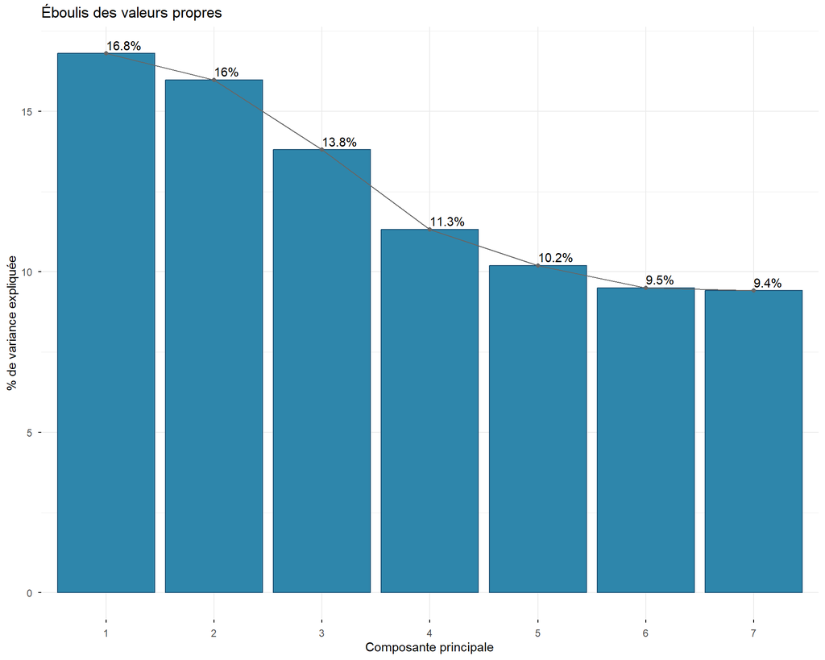

### 2.8.1 Cercle des corrélations

```
[1] "Dim.1" "Dim.2" "Dim.3" "Dim.4" "Dim.5"
```

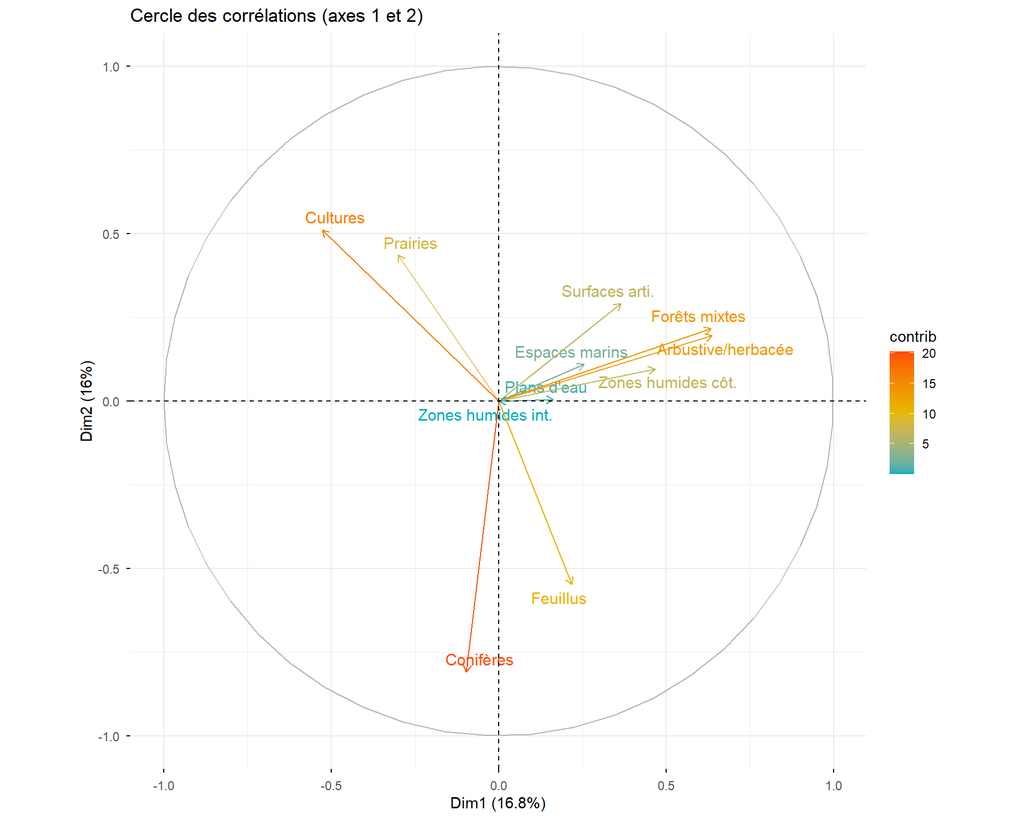

### 2.8.2 Contributions des variables

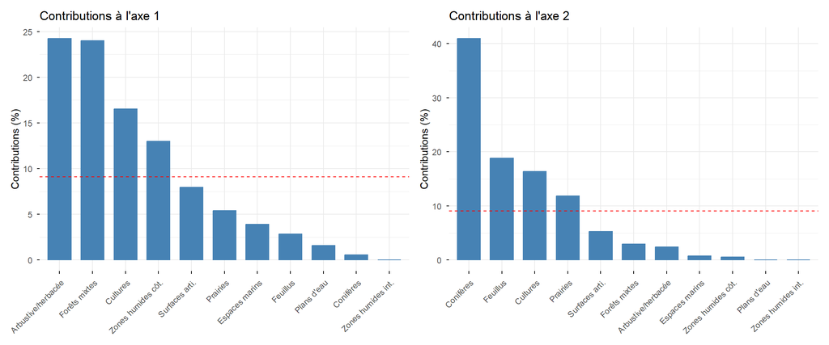

### 2.8.3 Tableau de corrélation PCA et clases CLC

📊 Corrélations entre les classes et les 5 premiers axes

| Variable | Axe 1 | Axe 2 | Axe 3 | Axe 4 | Axe 5 |
| --- | --- | --- | --- | --- | --- |
| Surfaces arti. | 0.366 | 0.291 | -0.726 | 0.147 | 0.231 |
| Feuillus | 0.219 | -0.549 | 0.257 | -0.449 | 0.145 |
| Conifères | -0.096 | -0.809 | 0.044 | 0.336 | -0.086 |
| Forêts mixtes | 0.635 | 0.217 | 0.434 | 0.274 | -0.008 |
| Arbustive/herbacée | 0.638 | 0.196 | 0.423 | -0.031 | -0.314 |
| Prairies | -0.301 | 0.436 | 0.247 | -0.511 | 0.425 |
| Cultures | -0.527 | 0.511 | 0.217 | 0.278 | -0.424 |
| Zones humides int. | 0.000 | 0.000 | 0.000 | 0.000 | 0.000 |
| Zones humides côt. | 0.467 | 0.096 | -0.206 | -0.416 | -0.268 |
| Plans d'eau | 0.163 | 0.005 | -0.499 | -0.040 | -0.247 |
| Espaces marins | 0.256 | 0.110 | 0.134 | 0.454 | 0.588 |

**TipAnalyse des Axes de l’ACP (Occupation du Sol)**

Les axes présentés correspondent à des gradients d’occupation du sol issus de l’Analyse en Composantes Principales (ACP). Chaque axe oppose deux ensembles de milieux contrastés, interprétés sur la base des charges composantes associées aux classes d’occupation du sol.

**Axe 1 : Gradient Naturel/Boisé vs Agricole/Cultivé**

[output not shown]

**Interprétation :** Gradient le plus fort, opposant clairement l’occupation du sol de type Naturel/Boisé à l’occupation de type Agricole/Cultivé.

**Axe 2 : Spécificité Forestière vs Agro-Artificiel**

Opposition Conifères/Feuillus vs Espaces Anthropisés

| Polarité | Description | Charges Significatives |
| --- | --- | --- |
| **Négative (−)** | Milieux **Forestiers Stricts** | Conifères : −0.81 Feuillus : −0.55 |
| **Positive (+)** | Milieux **Agricoles** et **Artificialisés** | Cultures : +0.51 Prairies : +0.43 Surfaces artificialisées : +0.29 |

**Interprétation :** Oppose spécifiquement les zones forestières (résineux et feuillus) aux zones soumises à l’activité humaine de type Agricole et Urbain.

**Axe 3 : Complexité Naturelle vs Artificialisation**

Milieux Naturels Hétérogènes vs Impact Anthropique

| Polarité | Description | Charges Significatives |
| --- | --- | --- |
| **Positive (+)** | Milieux **Naturels Complexes** et **Hétérogènes** | Forêts mixtes : +0.43 **A r b ustive/herbacée** +0.42 |
| **Négative (−)** | Surfaces à **Impact Anthropique** | Surfaces artificialisées : −0.72 Plans d’eau : −0.49 |

**Interprétation :** Oppose la complexité des milieux naturels terrestres à l’emprise humaine (artificialisation) et aux plans d’eau (souvent anthropiques).

**Axe 4 : Gradient Littoral**

| Polarité | Description | Charges Significatives |
| --- | --- | --- |
| **Positive (+)** | **Espaces Marins** | Espaces marins : +0.45 Conifères : +0.32 |
| **Négative (−)** | Milieux **Ouverts** et **Humides** | Prairies : −0.51 Z ones humides côtières : −0.41 |

**Interprétation :** Influencé par la distance à la mer, il oppose les Espaces Marins (et secondairement les conifères) à certains milieux ouverts et humides côtiers.

**Axe 5 : Maritimité vs Agriculture Intérieure**

Opposition Marine/Agricole

[output not shown]

## 2.9 Classification K-means

### 2.9.1 Détermination du nombre optimal de clusters

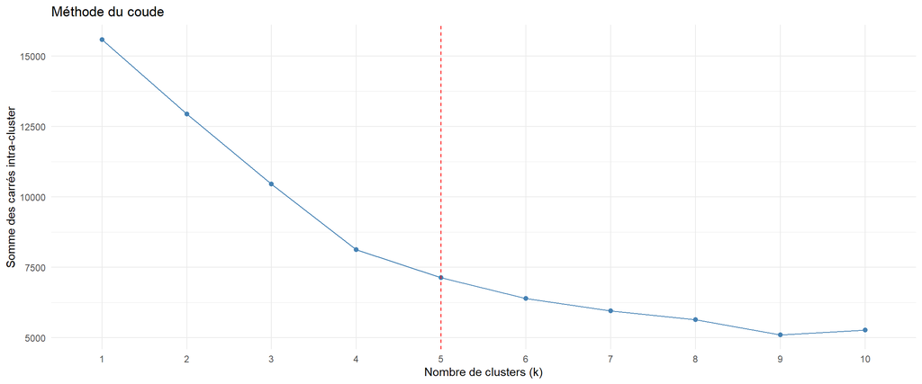

### 2.9.2 Application du K-means

```
🎯 Classification réalisée en 5 groupes
```

```
📊 Répartition des signalements par cluster:
```

```
  1   2   3   4   5
619 584  84 443 559
```

```
💯 Qualité du clustering (between_SS / total_SS): 54.29 %
```

**TipQualité de la classification**

📐 La Métrique : Between_SS / Total_SS Formule : (Between_SS / Total_SS) × 100

Total_SS = Variance totale des données (100%)

Between_SS = Variance entre les clusters (séparation)

Principe : Plus les clusters sont éloignés les uns des autres et compacts, plus le score est élevé.

📊 Signification de 54.29% de la variance expliquée par la séparation entre clusters

⚠️ 45.71% de la variance due à la dispersion interne (Within_SS)

✅ Points Positifs : Structure réelle détectée dans les données Clusters différenciés (pas aléatoire) Score normal pour des signalements (données complexes)

⚠️ Limites : 45% de variance reste inexpliquée donc des Clusters pas parfaitement séparés Possibilité d’amélioration

✅ Conclusion pour des signalements, 54.29% est acceptable mais pas optimal. L’important est de vérifier que vos 5 groupes ont une interprétation cohérente au-delà du chiffre statistique.

Échelle : < 40% (faible) | 40-60% (moyen) | 60-80% (bon) | > 80% (excellent).

### 2.9.3 Statistiques descriptives par cluster

Pourcentage moyen de chaque classe CLC+ par cluster

| Type d'occupation du sol | Cluster 1 | Cluster 2 | Cluster 3 | Cluster 4 | Cluster 5 |
| --- | --- | --- | --- | --- | --- |
| Surfaces arti. | 6.7 | 8.8 | 15.7 | 47.3 | 10.3 |
| Feuillus | 19.5 | 1.1 | 8.0 | 2.4 | 5.5 |
| Conifères | 51.3 | 21.8 | 14.0 | 20.5 | 22.7 |
| Forêts mixtes | 0.0 | 0.0 | 7.8 | 0.1 | 0.0 |
| Arbustive/herbacée | 1.2 | 0.9 | 26.8 | 1.1 | 1.0 |
| Prairies | 16.3 | 22.0 | 20.4 | 18.6 | 46.5 |
| Cultures | 4.0 | 44.0 | 5.4 | 4.5 | 12.8 |
| Zones humides int. | 0.0 | 0.0 | 0.0 | 0.0 | 0.0 |
| Zones humides côt. | 0.3 | 0.2 | 1.6 | 1.0 | 0.3 |
| Plans d'eau | 0.7 | 0.9 | 0.3 | 4.5 | 0.8 |
| Espaces marins | 0.0 | 0.0 | 0.0 | 0.0 | 0.0 |

**TipTypologie paysagère identifiée**

**Cluster 1 – Pyasages forestiers**

- Conifères très majoritaires (51,3 %),
- avec une part notable de feuillus (19,5 %) et de prairies (16,3 %).
- Très peu de surfaces artificialisées.
- 👉 **Profil** : territoires majoritairement forestiers, plutôt naturels ou semi-naturels, typiques de zones montagnardes ou peu anthropisées.

**Cluster 2 – Territoires agricoles-prairies**

- Cultures dominantes (44,0 %) et prairies importantes (22,0 %).
- Présence secondaire de conifères (21,8 %) et Artificialisation faible.
- 👉 **Profil** : paysages agro-pastoraux, à vocation agricole marquée, avec une mosaïque cultures–prairies–forêts.

**Cluster 3 – Milieux ouverts semi-naturels**

- Forte proportion de formations arbustives/herbacées (26,8 %).
- Parts équilibrées de prairiesn(20,4 %), conifères (14,0 %) et surfaces artificielles (15,7 %).
- 👉 **Profil :** territoires de transition, combinant espaces naturels ouverts, activités humaines et urbanisation modérée (zones périurbaines, friches, garrigues, landes).

**Cluster 4 – Espaces fortement urbanisés**

- Surfaces artificialisées très dominantes (47,3 %).
- Compléments de prairies (18,6 %), conifères (20,5 %) et plans d’eau (4,5 %).
- 👉 **Profil :** zones urbaines et périurbaines et quelques espaces verts ou naturels résiduels.

**Cluster 5 – Paysages prairiaux et ruraux**

- Prairies très majoritaires (46,5 %).
- Parts secondaires de conifères (22,7 %), cultures (12,8 %) et surfaces artificielles modérées.
- 👉 **Profil :** territoires ruraux extensifs, souvent liés à l’élevage, avec une anthropisation faible à modérée.

## 2.10 Cartographie de l’environnement de piqûre

**Remplissage label selon les clusters**

**Répartition par profil paysager**

[interactive chart not shown]

**Visualisation dans l’espace PCA**

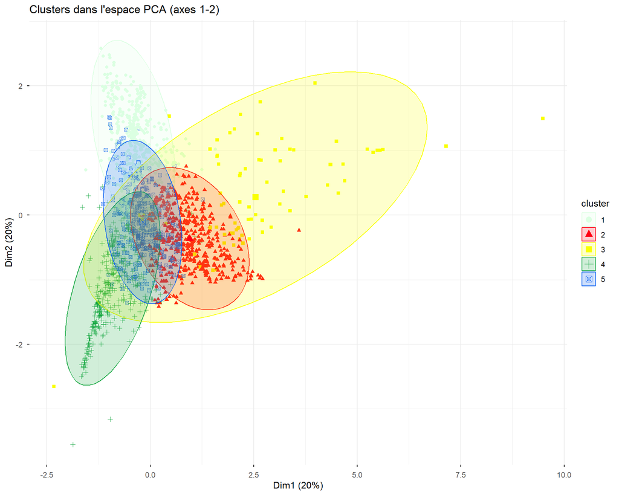

## 2.11 Synthèse des typologies paysagères

Synthèse des typologies paysagères par cluster

| cluster | N | Urbain (%) | Forêt (%) | Agriculture (%) | Prairie (%) |
| --- | --- | --- | --- | --- | --- |
| 1 | 619 | 6.7 | 70.8 | 4.0 | 16.3 |
| 2 | 584 | 8.8 | 23.0 | 44.0 | 22.0 |
| 3 | 84 | 15.7 | 29.8 | 5.4 | 20.4 |
| 4 | 443 | 47.3 | 22.9 | 4.5 | 18.6 |
| 5 | 559 | 10.3 | 28.3 | 12.8 | 46.5 |

**Répartition des signalements par envionnement de piqûre**

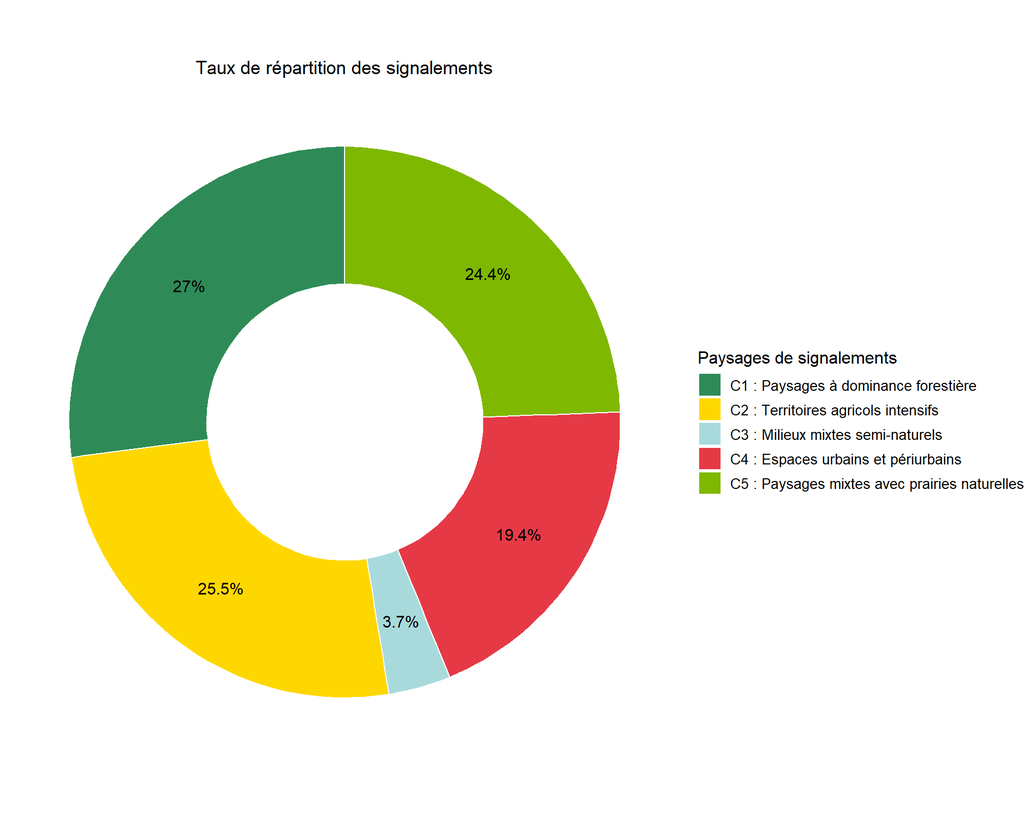

**Répartition de signalement selon paysage déclaré et profils analysés**

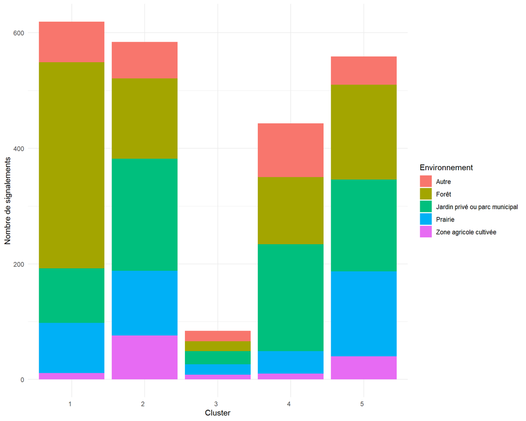

**signalements par région et environnement analysé**

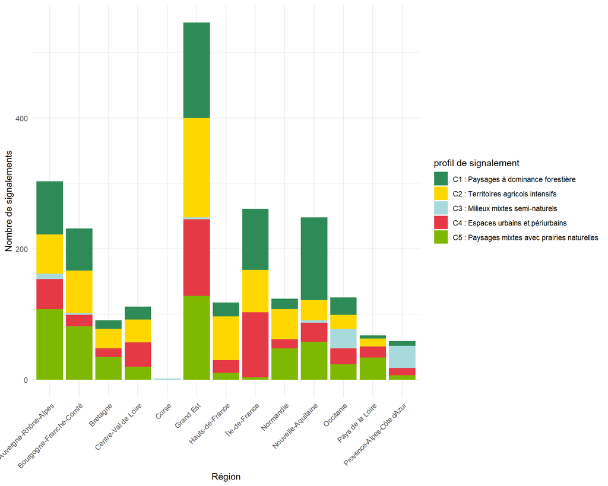

# 3 Export des données